# DISSECTING TIKTOK

#### Created by Bailey Breving, Cade Thomas, ElseLucia Knudsen, Felix Varas, Jessica Lucas, & Libby Graalum

## Will they Actually Like & Share?

##### by ElseLucia Knudsen

The graphs below show the correlation between how many views a TikTok got with how many likes and shares it also got. In theory, for someone to get the most viral they can is not just about views, the video also needs likes and shares. Using this graph we can analyze if a video with a lot of views also has a lot of likes and shares. If there are outliers in this pattern we would want to look into why that video got popular without the three ingredients that normally are needed to go viral. The first graph shows all of our data points, the graph tells us that there are very few videos that get a high number of Views, Likes, and Shares. The second graph zooms in and excludes those large outliers. This is useful to observe the most common combination of Views, Likes, and Shares. The last graph shows just the outliers. This is helpful because we can study what the best combination is for maximum viral potential.

### If They See It, Will They Like & Share?

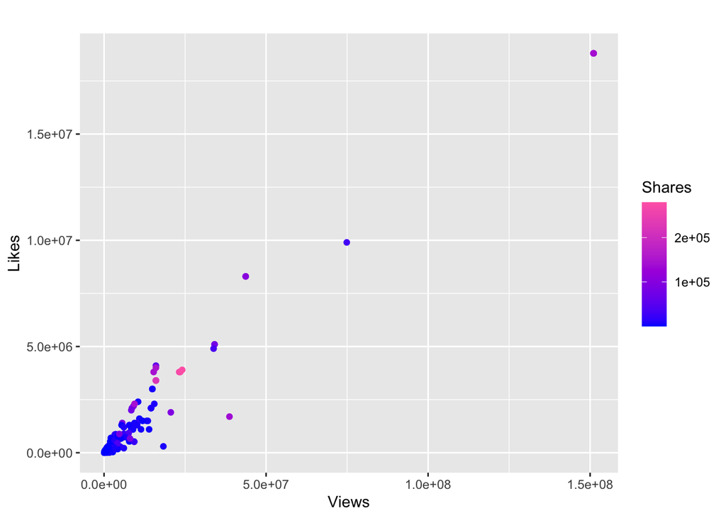

### Will They Like & Share? (Minus Outliers)

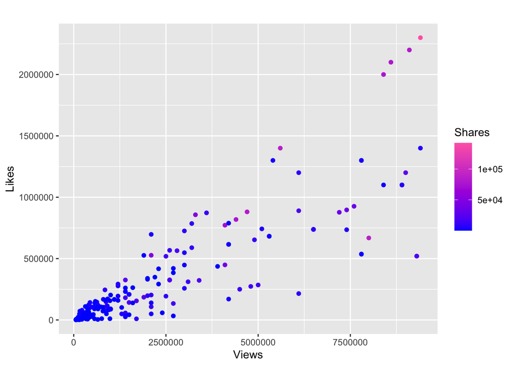

### Will They Like & Share? (Only Outliers)

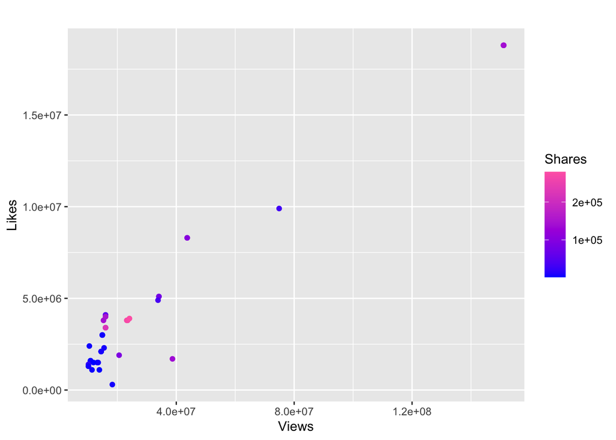

## Correlation Between the Number of Likes a Video Has and Whether Or Not It Was Posted by a Verified User

##### by Cade Thomas

This graph compares the number of likes on the posts of Verified users and Unverified users. As it turns out, there are larger more isolated instances of verified users getting a lot of likes. And for the unverified users they don't have a lot of likes but they do have a very high volume of likes. This shows that unverified users getting lucky on Tik Tok reach more viewers than some of the verified users.

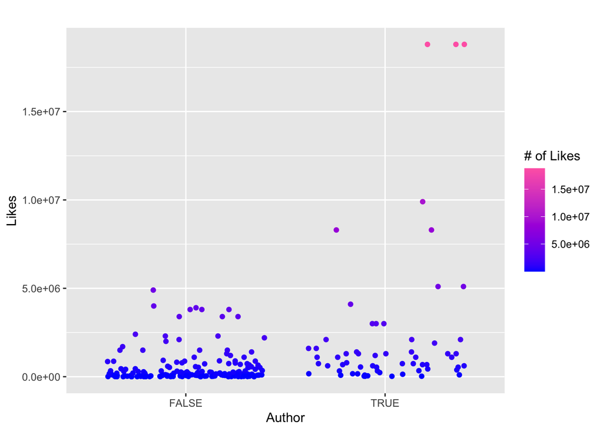

## Correlation Between Video Duration and Video Likes

##### by Bailey Breving

There is a trend in video likes declining the longer the TikTok video duration. There is no correlation between user popularity and verified user status. Shorter videos receive more likes than longer videos.

### Video Duration vs. Video Likes

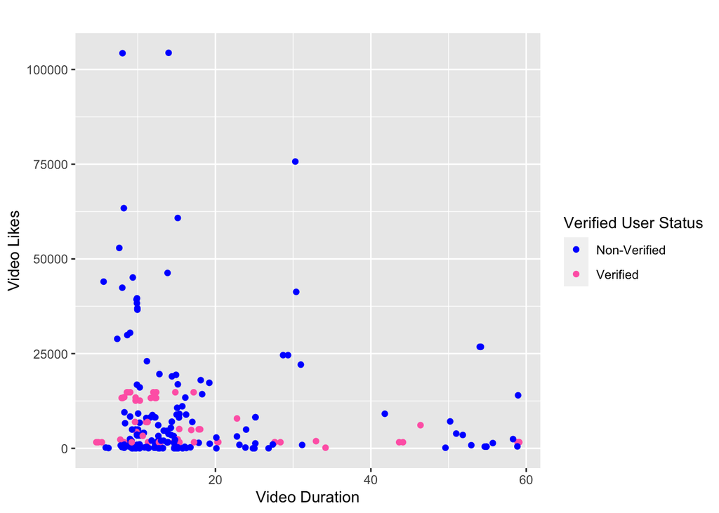

Taking a closer look: There is a strong correlation between shorter videos ranging between 10-20 seconds that receive the majority of likes. Interestingly enough, the “Verified Users” seem to plateau in their video likes no matter the duration of their TikTok videos.

### Video Duration vs. Video Likes

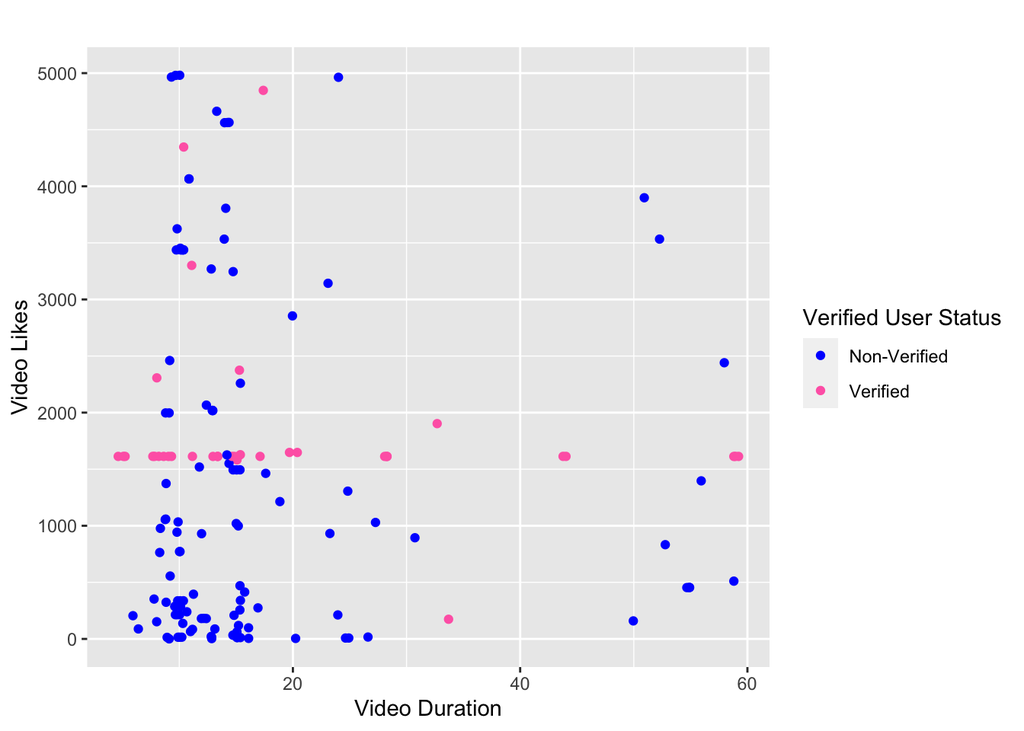

## Correlation of Video Duration, Likes, & Shares

### Correlation Between Video Duration and Share Count by Their Number of Likes

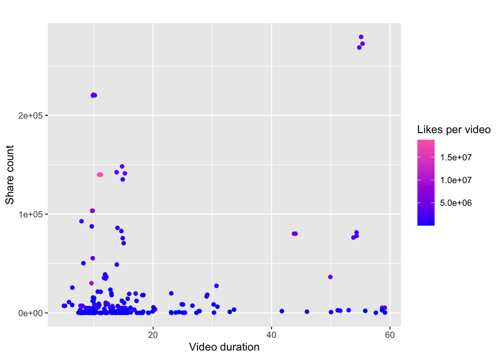

### Correlation Between Video Duration (videos under 20 sec.) and Share Count by Their Number of Likes

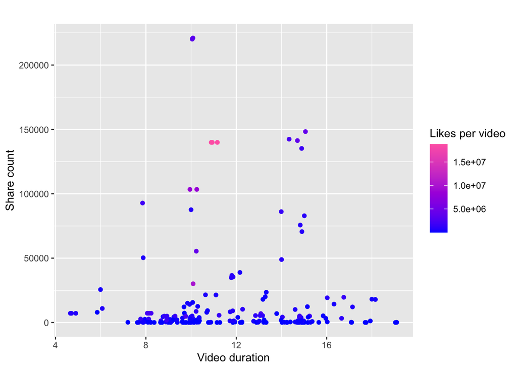

### Correlation Between Video Duration (videos over 20 sec.) and Share Count by Their Number of Likes

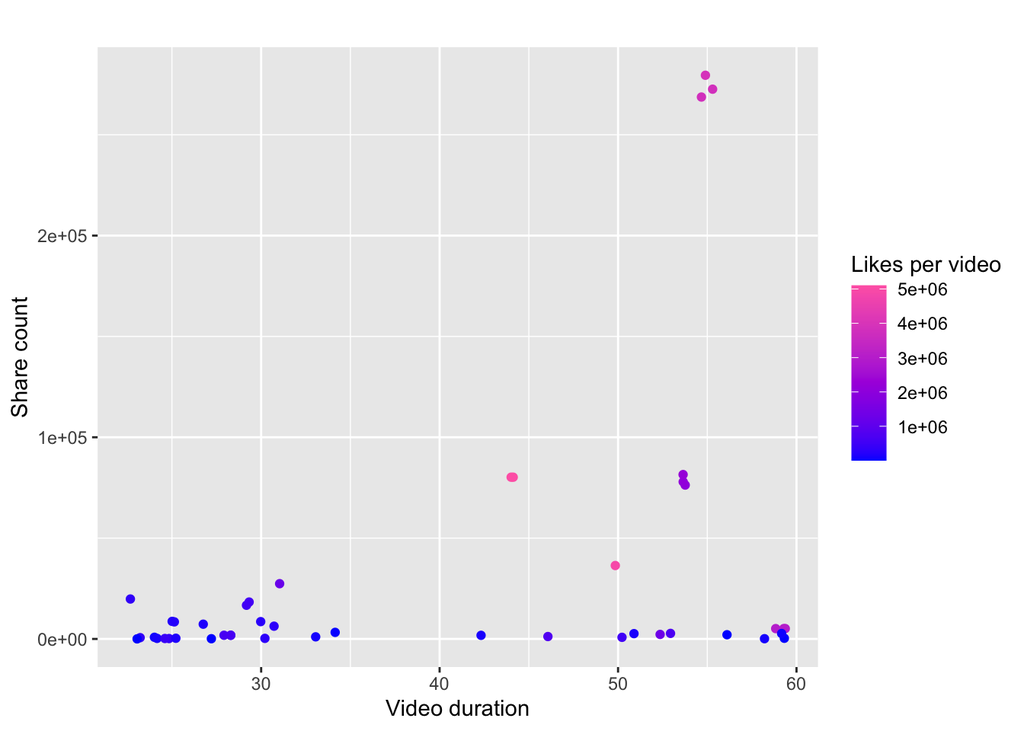

## Username Verification with View, Comments, and Shares

##### by Jessica Jucas

Here is a graph that shows the correlation between a Tik Tok creator's username and their video play count. This graph also combines data that shows each video's comment and share count for each of those videos, based on the size and color of each data point. The shape of each plotted point reference if that particular Tik Tok creator is verified or not within the app. This graph shows what you would predict within the Tik Tok community, that the more views a video gets, the more shares and comments it will get as well. Most videos that make it to such a high view count are from verified creators, however, there were a larger number of outliers of unverified users than one would expect.

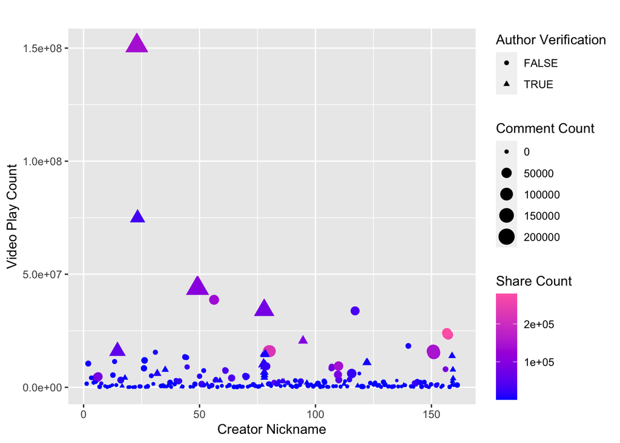

## Network of Words used in Descriptions

##### by Libby Graalum

This network consists of the corpus connections between words and hashtags used in the description of featured TikToks. As seen in the center, the hashtag "fyp" a.k.a. "for your page" has the high occurrences. The coloring of the nodes represents the modularities in the dataset.

[figure not shown]